# How Lucky Was Alpharad?

Pokelytics

2024-08-31

After watching Alpharad’s latest [youtube video](https://www.youtube.com/watch?v=lhDIz97t5iQ), I was curious about his overall luck in catching shiny pokemon.

I wanted to calculate his best and worst luck, and look at his overall luck.

## Shiny Odds in Pokemon Let’s Go

Typically in Pokemon Let’s Go, the odds of encountering a shiny pokemon are 1 in 4096. However, there is a catch combo mechanic that increases shiny odds as the number of consecutively caugtht pokemon of the same species increases.

The odds are represented by this table.

| Catch Combo | Shiny Odds |
| --- | --- |
| 1-10 | 1/4096 |
| 11-20 | 1/1024 |
| 21-30 | 1/512 |
| 31+ | 3/1024 |

To calculate the odds of catching a pokemon by a certain encounter (assuming a catch combo greater than 30), we can use the following formula:

$P(x)=1-((\frac{4095}{4096})^{10}*(\frac{1023}{1024})^{10}(\frac{511}{512})^{10}(\frac{1021}{1024})^{x-30})$

## Best Luck

His best luck was his Charmander, which he caught in 23 encounters.

```r
1-((4095/4096)^10*(1023/1024)^10*(511/512)^3)
```

```
## [1] 0.01791479
```

Wow! Not even a 2% chance! Very lucky Alpharad.

## Worst Luck

His worst luck was Tentacool, which took 1041 encounters.

```r
1-((4095/4096)^10*(1023/1024)^10*(511/512)^10*(1021/1024)^1011)
```

```
## [1] 0.9501144
```

There was a 95% chance he would have caught it by then. That means there is only a 5% chance it would take him that long. Poor guy.

## Expected Value of Encounters

Let’s calculate the expected value of encounters for Alpharad to catch a shiny pokemon.

The expected value for a given probability *p* is $\frac{1} {p}$, but this probability changes with encounters, so it is not so simple.

```r
# Define the probabilities and ranges
probabilities <- c(1/4096, 1/1024, 1/512, 3/1024)
ranges <- c(10, 10, 10, Inf)

# Initialize variables
expected_value <- 0
cumulative_prob <- 1

# Calculate the expected value
for (i in seq_along(probabilities)) {
  if (is.infinite(ranges[i])) {
    expected_value <- expected_value + (cumulative_prob / probabilities[i])
  } else {
    prob_of_not_shiny <- (1 - probabilities[i]) ^ ranges[i]
    expected_value <- expected_value + (cumulative_prob * (1 - prob_of_not_shiny) / probabilities[i])
    cumulative_prob <- cumulative_prob * prob_of_not_shiny
  }
}

# Output the expected value
expected_value
```

```
## [1] 360.3753
```

360.37 is the expected number of encounters.

## Overall Luck

Alpharad caught 16 pokemon through combo chaining.

```r
shinies <- read.csv("~/alpharad_shinies.csv")

shinies
```

```
##       Pokemon Catches
## 1   Nidoran-M     600
## 2  Bellsprout     550
## 3      Vulpix     729
## 4      Weedle     144
## 5  Charmander      23
## 6     Psyduck      77
## 7      Pidgey     194
## 8    Caterpie     833
## 9   Nidoran-F      85
## 10     Gastly     145
## 11    Ratatta     346
## 12    Poliwag     741
## 13    Diglett     129
## 14  Tentacool    1041
## 15   Magikarp      65
## 16    Geodude      67
```

Since each pokemon is separate, the expected value of encounters for 16 is 16 times the expected value of encounters for 1.

```r
sum(shinies$Catches)
```

```
## [1] 5769
```

```r
16*expected_value
```

```
## [1] 5766.004
```

Wow! His luck was very average!

Let’s plot it.

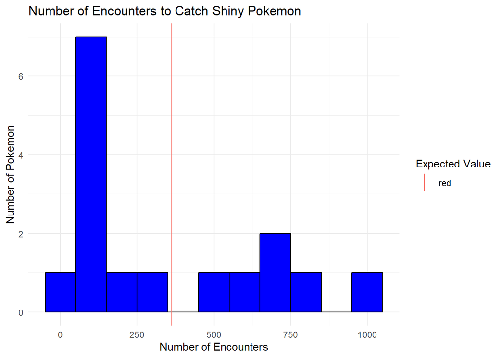

```r
library(ggplot2)
#histogram

ggplot(shinies, aes(x = Catches)) +
  geom_histogram(binwidth = 100, fill = "blue", color = "black") +
  geom_vline(aes(xintercept= expected_value, color = "red")) +
  labs(title = "Number of Encounters to Catch Shiny Pokemon",
       x = "Number of Encounters",
       y = "Number of Pokemon",
       color = "Expected Value") +
  theme_minimal()
```

He caught 10 pokemon in fewer encounters than expected, and 6 in more than expected, but he got really unlucky with a few of them. Overall he had extremely average luck.